# Scaling at each node: Experiment 01

Jesse L. Patsolic

2019-01-23

# Introduction

## Toy dataset

Consider the regions described by the sets

$O = \{(x_1, x_2) | \, x_1 \in (10^{-4}, 10^{-3}), x_2 \in (10^4, 10^5), x_2 < 10^8 \cdot x_1)\}$

$X = \{(x_1, x_2) | \, x_1 \in (10^{-4}, 10^{-3}), x_2 \in (10^4, 10^5), x_2 > 10^8 \cdot x_1)\}$

Points in class 0 will be sampled from region $O$ and points in class 1 will be sampled from region $X$.

```r
n1 <- 1e3
n2 <- 1e3

rx1 <- c(1e-4, 1e-3)
rx2 <- c(1e4, 1e5)
(m <- diff(rx2) / diff(rx1))
```

```
#> [1] 1e+08
```

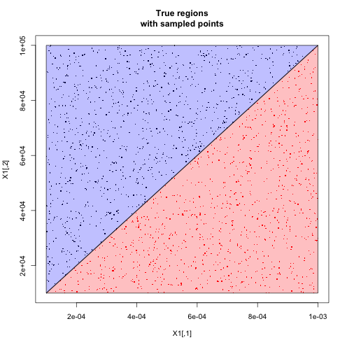

```r
ymxb <- function(x) m * x

xb <- c(1e-4, 1e-3)
yb <- c(1e4, 1e5)

xb  <- c(seq(1e-4, 1e-3, length = 5), 1e-3, 1e-4)
yb  <- c(ymxb(xb[-c(6,7)]), 1e4, 1e4)
yb2  <- c(ymxb(xb[-c(6,7)]), 1e5, 1e5)

set.seed(1234)
x11 <- runif(4*n1, rx1[1], rx1[2])
x12 <- runif(4*n2, rx2[1], rx2[2])

Y1o <- (x12 < (m * x11)) + 1

Y1o.ind <- c(sample(which(Y1o == 1), n1), sample(which(Y1o == 2), n2))

Y1 <- Y1o[Y1o.ind]
X1 <- cbind(x11[Y1o.ind], x12[Y1o.ind])

#plot(X1, col = Y1, pch = '.', xlim = rx1, ylim = rx2)
#curve(ymxb, rx1[1],rx1[2], add = TRUE)

plot(X1, col = Y1, type = 'p', pch = '.', cex = 2, main = "True regions
with sampled points")

polygon(x = xb, y = yb, col= scales::alpha('red', 0.25))
polygon(x = xb, y = yb2, col= scales::alpha('blue', 0.25))
```

## Train some forests

```r
FUN <- RandMatBinary
num.cores <- 1L
paramList <- list(p = 2, d = 3, sparsity = 1, prob = 0.5)
ntrees <- 1L
```

```r
seed <- 2

f1 <- RerF(X1, Y1, FUN = FUN, paramList = paramList, scaleAtNode = FALSE, trees = ntrees, max.depth = 2L, store.oob = TRUE, store.impurity = TRUE, num.cores = num.cores, seed = seed)
f1.pred <- Predict(X1, f1)

f1s <- RerF(X1, Y1, FUN = FUN, paramList = paramList, scaleAtNode = TRUE, trees = ntrees, max.depth = 2L, store.oob = TRUE, store.impurity = TRUE, num.cores = num.cores, seed = seed)
f1s.pred <- Predict(X1, f1s)

RcppZiggurat::zsetseed(seed)
f1c <- RerF(X1, Y1, FUN = RandMatContinuous,  paramList = paramList, scaleAtNode = FALSE, trees = ntrees, max.depth = 2L, store.oob = TRUE, store.impurity = TRUE, num.cores = num.cores, seed = seed)
f1c.pred <- Predict(X1, f1c)
```

### Scaled forest (RandMatBinary)

| nodeNum | LC | RC | CutValue | nodeClass | classProb | CutFeature |
| --- | --- | --- | --- | --- | --- | --- |
| 1 | 2 | 3 | 0.00078284298691482651078 | NA | 0 | c(1, 1, 2, -1) |
| 2 | NA | NA | NA | 1 | 1 | NA |
| 3 | NA | NA | NA | 2 | 1 | NA |

#### Confusion matrix

| 1 | 2 |
| --- | --- |
| 1000 | 0 |
| 0 | 1000 |

#### Percent error

```r
sum(f1s.pred != Y1) / length(Y1)
```

```
#> [1] 0
```

### Un-scaled forest (RandMatBinary)

```r
kable(PrintTree(f1, 1))
```

| nodeNum | LC | RC | CutValue | nodeClass | classProb | CutFeature |
| --- | --- | --- | --- | --- | --- | --- |
| 1 | 2 | 3 | -50383.207746771506208 | NA | 0.00000000000000000000 | c(1, 1, 2, -1) |
| 2 | NA | NA | NA | 1 | 0.75115207373271897229 | NA |
| 3 | NA | NA | NA | 2 | 0.79781420765027322162 | NA |

#### Confusion matrix

| 1 | 2 |
| --- | --- |
| 811 | 286 |
| 189 | 714 |

#### Percent error

```r
sum(f1.pred != Y1) / length(Y1)
```

```
#> [1] 0.2374999999999999889
```

### Un-scaled forest (RandMatContinuous)

```r
kable(PrintTree(f1c, 1))
```

| nodeNum | LC | RC | CutValue | nodeClass | classProb | CutFeature |
| --- | --- | --- | --- | --- | --- | --- |
| 1 | 2 | 3 | -31225.269465987839794 | NA | 0.00000000000000000000 | c(1, -0.429629889503567, 2, -0.619755479800801) |
| 2 | NA | NA | NA | 1 | 0.75115207373271897229 | NA |
| 3 | NA | NA | NA | 2 | 0.79781420765027322162 | NA |

#### Confusion matrix

| 1 | 2 |
| --- | --- |
| 811 | 286 |
| 189 | 714 |

#### Percent error

```r
sum(f1c.pred != Y1) / length(Y1)
```

```
#> [1] 0.2374999999999999889
```

## Plotting the learned decision boundaries on the projected data

```r
cutV <- PrintTree(f1s, 1)$CutV[1]

mins <- apply(X1, 2, min)
diff <- apply(X1, 2, max) - mins

X1s <- sweep(sweep(X1, MARGIN = 2, STATS = mins, "-"), MARGIN = 2, STATS = diff, FUN = "/")

sparseM <- matrix(c(1,-1))
A <- X1s %*% sparseM

par(mfrow = c(1,3))
plot(cbind(A, Y1), col = Y1, pch = 19)
abline(v = cutV)
title("Scaled")

PrintTree(f1, 1)
```

```
#>   nodeNum LC RC               CutValue nodeClass              classProb
#> 1       1  2  3 -50383.207746771506208        NA 0.00000000000000000000
#> 2       2 NA NA                     NA         1 0.75115207373271886127
#> 3       3 NA NA                     NA         2 0.79781420765027322162
#>    CutFeature
#> 1 1, 1, 2, -1
#> 2          NA
#> 3          NA
```

```r
cutV <- PrintTree(f1, 1)$CutV[1]
cutF <- PrintTree(f1, 1)$CutF[[1]][c(2,4)]

sparseM <- matrix(cutF)
A <- X1 %*% sparseM

plot(cbind(A, Y1), col = Y1, pch = 19)
abline(v = cutV)
title("Un-Scaled")

PrintTree(f1c, 1)
```

```
#>   nodeNum LC RC               CutValue nodeClass              classProb
#> 1       1  2  3 -31225.269465987839794        NA 0.00000000000000000000
#> 2       2 NA NA                     NA         1 0.75115207373271886127
#> 3       3 NA NA                     NA         2 0.79781420765027322162
#>                                                                                         CutFeature
#> 1 1.00000000000000000000, -0.42962988950356711948, 2.00000000000000000000, -0.61975547980080147870
#> 2                                                                                               NA
#> 3                                                                                               NA
```

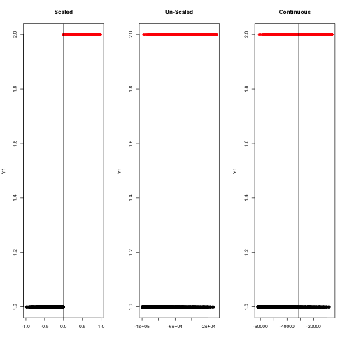

```r
cutV <- PrintTree(f1c, 1)$CutV[1]
cutF <- PrintTree(f1c, 1)$CutF[[1]][c(2,4)]

sparseM <- matrix(cutF)
A <- X1 %*% sparseM


plot(cbind(A, Y1), col = Y1, pch = 19)
abline(v = cutV)
title("Continuous")
```

```r
#plot(X1, col = Y1, type = 'p', pch = '.', cex = 2, main = "True regions
#with sampled points")
#polygon(x = xb, y = yb, col= scales::alpha('red', 0.25))
#polygon(x = xb, y = yb2, col= scales::alpha('blue', 0.25))
#v1 <- c(1e-4, 1e-3)
#v2 <- c(1e4, 1e5)
#V <- rbind(v1, -v1, v2, -v2)
#v3 <- v1 - v2
#v3 <- v1 - v2
#plot(V)
#arrows(v1[1], v3[1], v1[2], v3[2])
#arrows(v1[1], v2[1], v1[2], v2[2])
```

## Toy dataset 2

Consider the regions described by the sets

$O = \{(x_1, x_2) | \, x_1 \in (10^{-4}, 10^{-3}), x_2 \in (10^4, 10^5 + \epsilon), x_2 > 10^8 \cdot x_1)\} \cup \\ \{(x_1, x_2) | \, x_1 \in (10^{-3}, 10^{3}), x_2 \in (10^5, 10^5 + \epsilon), x_2 < \frac{1}{999999} \cdot x_1 + \frac{99999899999999}{999999000}\} \\$

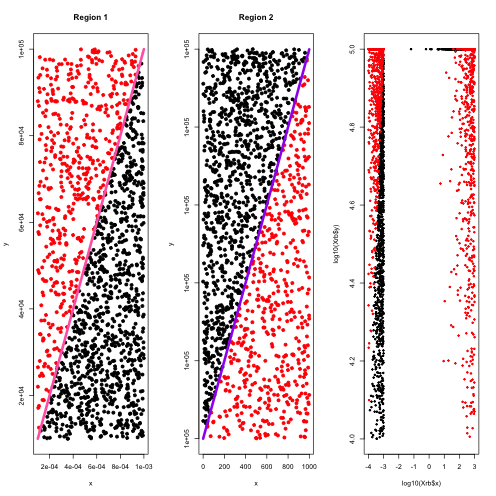

```r
#plot(X1, col = Y1, pch = 19)
n1 <- 4e3

eps <- 1e-5

ax1 <- c(1e-4, 1e-3)
ay1 <- c(1e4, 1e5)

ax2 <- c(1e-3, 1e3)
ay2 <- c(1e5, 1e5 + eps)


px <- runif(n1, ax1[1], ax1[2])
py <- runif(n1, ay1[1], ay1[2])

R1 <- data.frame(x = px, y = py)

m1 <- diff(ay1) / diff(ax1)
b1 <- 0
l1 <- function(x) m1 * x + b1

ind1 <- R1$y < l1(R1$x)

Xr1 <- R1[ind1, ][1:1e3, ]
Or1 <- R1[!ind1, ][1:500, ]

#plot(Xr1)
#plot(Or1)

qx <- runif(n1, ax2[1], ax2[2])
qy <- runif(n1, ay2[1], ay2[2])

R2 <- data.frame(x = qx, y = qy)

m2 <- diff(ay2) / diff(ax2)
b2 <- ay2[1] - (m2 * ax2[1])
l2 <- function(x) m2 * x + b2

ind2 <- R2$y > l2(R2$x)

Xr2 <- R2[ind2, ][1:1e3, ]
Or2 <- R2[!ind2, ][1:500, ]


Or3 <- data.frame(x = runif(n1, ax2[1], ax2[2]),
                  y = runif(n1, ay1[1], ay1[2]))[1:500, ]

Or4 <- data.frame(x = runif(n1, ax1[1], ax1[2]),
                  y = runif(n1, ay2[1], ay2[2]))[1:500, ]


Y <- rep(c(1,2), each = 2e3)
par(mfrow = c(1,3))
plot(rbind(Xr1, Xr2, Or1, Or2), col = Y, xlim = c(1e-4, 1e-3), pch = 19)
title("Region 1")
curve(l1, 1e-4, 1e-3, add = TRUE, lwd = 4, col = 'hotpink')

plot(rbind(Xr1, Xr2, Or1, Or2), col = Y, ylim = c(1e5, 1e5 + eps), pch = 19)
title("Region 2")
curve(l2, lwd = 4, col = 'purple', add = TRUE)

Xrb <- data.frame(rbind(Xr1, Xr2, Or1, Or2, Or3, Or4))
Yrb <- rep(c(1,2), each = 2e3)

plot(log10(Xrb$x), log10(Xrb$y), col = Yrb, pch = 19, cex = 0.5)
```

## Train some forests

```r
FUN <- RandMatBinary
mdepth <- 4L
num.cores <- 1L
paramList <- list(p = 2, d = 4, sparsity = 0.5, prob = 0.5)
ntrees <- 1L
```

```r
seed <- 1234
set.seed(seed)

f2 <- RerF(Xrb, Yrb, FUN = FUN, paramList = paramList, scaleAtNode = FALSE, trees = ntrees, max.depth = mdepth, store.oob = TRUE, store.impurity = TRUE, num.cores = num.cores, seed = seed)
f2.pred <- Predict(Xrb, f2)

f2s <- RerF(Xrb, Yrb, FUN = FUN, paramList = paramList, scaleAtNode = TRUE, trees = ntrees, max.depth = mdepth, store.oob = TRUE, store.impurity = TRUE, num.cores = num.cores, seed = seed)
f2s.pred <- Predict(Xrb, f2s)

RcppZiggurat::zsetseed(seed)
f2c <- RerF(Xrb, Yrb, FUN = RandMatContinuous,  paramList = paramList, scaleAtNode = FALSE, trees = ntrees, max.depth = mdepth, store.oob = TRUE, store.impurity = TRUE, num.cores = num.cores, seed = seed)
f2c.pred <- Predict(Xrb, f2c)
```

### Scaled forest (RandMatBinary)

| nodeNum | LC | RC | CutValue | nodeClass | classProb | CutFeature |
| --- | --- | --- | --- | --- | --- | --- |
| 1 | 2 | 3 | -0.99713141404619587415681 | NA | 0.00000000000000000000 | c(1, 1, 2, -1) |
| 2 | NA | NA | NA | 2 | 1.00000000000000000000 | NA |
| 3 | 4 | 5 | -0.00157709342517299523287 | NA | 0.00000000000000000000 | c(1, 1, 2, -1) |
| 4 | 6 | 7 | 0.99999999995434241117920 | NA | 0.00000000000000000000 | 2:1 |
| 5 | 8 | 9 | 0.00064721811479437883242 | NA | 0.00000000000000000000 | 2:1 |
| 6 | NA | NA | NA | 1 | 0.54083266613290637004 | NA |
| 7 | NA | NA | NA | 1 | 0.90502793296089378838 | NA |
| 8 | NA | NA | NA | 1 | 1.00000000000000000000 | NA |
| 9 | NA | NA | NA | 2 | 1.00000000000000000000 | NA |

#### Confusion matrix

| 1 | 2 |
| --- | --- |
| 1994 | 1246 |
| 6 | 754 |

#### Percent error

```r
sum(f2s.pred != Yrb) / length(Yrb)
```

```
#> [1] 0.31300000000000000044
```

### Un-scaled forest (RandMatBinary)

```r
kable(PrintTree(f2, 1))
```

| nodeNum | LC | RC | CutValue | nodeClass | classProb | CutFeature |
| --- | --- | --- | --- | --- | --- | --- |
| 1 | 2 | 3 | -99998.055958967015613 | NA | 0.00000000000000000000 | c(1, 1, 2, -1) |
| 2 | NA | NA | NA | 2 | 1.00000000000000000000 | NA |
| 3 | 4 | 5 | -99502.518756877791020 | NA | 0.00000000000000000000 | c(1, 1, 2, -1) |
| 4 | 6 | 7 | 100000.000002735789167 | NA | 0.00000000000000000000 | 2:1 |
| 5 | 8 | 9 | -53122.028860783240816 | NA | 0.00000000000000000000 | c(1, -1, 2, -1) |
| 6 | NA | NA | NA | 2 | 0.53968253968253965258 | NA |
| 7 | NA | NA | NA | 1 | 0.97083333333333332593 | NA |
| 8 | NA | NA | NA | 2 | 0.67516778523489928698 | NA |
| 9 | NA | NA | NA | 1 | 0.67717996289424864376 | NA |

#### Confusion matrix

| 1 | 2 |
| --- | --- |
| 1387 | 367 |
| 613 | 1633 |

#### Percent error

```r
sum(f2.pred != Yrb) / length(Yrb)
```

```
#> [1] 0.24499999999999999556
```

### Un-scaled forest (RandMatContinuous)

```r
kable(PrintTree(f2c, 1))
```

| nodeNum | LC | RC | CutValue | nodeClass | classProb | CutFeature |
| --- | --- | --- | --- | --- | --- | --- |
| 1 | 2 | 3 | -3087.581796836137073115 | NA | 0.00000000000000000000 | c(1, -0.0854142720525509, 2, -0.0308741574733843) |
| 2 | 4 | 5 | -265.081052889371903802 | NA | 0.00000000000000000000 | c(1, -0.401463970115571) |
| 3 | 10 | 11 | -7273.461407156140012376 | NA | 0.00000000000000000000 | c(1, -0.160451814155261, 2, -0.113333221265021) |
| 4 | 6 | 7 | 196490.674737516179447994 | NA | 0.00000000000000000000 | c(1, -0.10992633447451, 2, 1.96580836722054) |
| 5 | 8 | 9 | 23.169534821088532794 | NA | 0.00000000000000000000 | c(1, 0.072570268961757) |
| 6 | NA | NA | NA | 2 | 0.92485549132947975082 | NA |
| 7 | NA | NA | NA | 2 | 0.59895833333333337034 | NA |
| 8 | NA | NA | NA | 1 | 0.93645484949832780153 | NA |
| 9 | NA | NA | NA | 1 | 0.68471953578336552937 | NA |
| 10 | 12 | 13 | -22857.655553319695172831 | NA | 0.00000000000000000000 | c(1, -1.30715615259347, 2, -0.247875464621778) |
| 11 | 14 | 15 | 10745.125937845563385054 | NA | 0.00000000000000000000 | c(2, 0.316911964988905) |
| 12 | NA | NA | NA | 2 | 0.99393019726858877760 | NA |
| 13 | NA | NA | NA | 2 | 0.72893772893772890153 | NA |
| 14 | NA | NA | NA | 1 | 0.75118110236220470011 | NA |
| 15 | NA | NA | NA | 1 | 0.53970588235294114643 | NA |

#### Confusion matrix

| 1 | 2 |
| --- | --- |
| 1729 | 681 |
| 271 | 1319 |

#### Percent error

```r
sum(f2c.pred != Yrb) / length(Yrb)
```

```
#> [1] 0.23799999999999998934
```

## Plotting the learned decision boundaries on the projected data

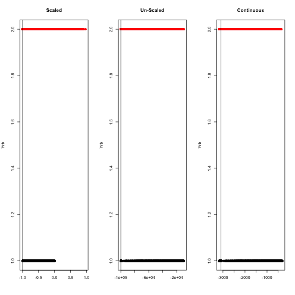

```
#>   nodeNum LC RC               CutValue nodeClass              classProb
#> 1       1  2  3 -99998.055958967015613        NA 0.00000000000000000000
#> 2       2 NA NA                     NA         2 1.00000000000000000000
#> 3       3  4  5 -99502.518756877791020        NA 0.00000000000000000000
#> 4       4  6  7 100000.000002735789167        NA 0.00000000000000000000
#> 5       5  8  9 -53122.028860783240816        NA 0.00000000000000000000
#> 6       6 NA NA                     NA         2 0.53968253968253965258
#> 7       7 NA NA                     NA         1 0.97083333333333332593
#> 8       8 NA NA                     NA         2 0.67516778523489928698
#> 9       9 NA NA                     NA         1 0.67717996289424864376
#>     CutFeature
#> 1  1, 1, 2, -1
#> 2           NA
#> 3  1, 1, 2, -1
#> 4         2, 1
```

[output cut: 53 more lines]

```r
cutV <- PrintTree(f2s, 1)$CutV[1]
cutF <- PrintTree(f2s, 1)$CutF[[1]][c(2,4)]

mins <- apply(Xrb, 2, min)
diff <- apply(Xrb, 2, max) - mins

Xrbs <- sweep(sweep(Xrb, MARGIN = 2, STATS = mins, "-"), MARGIN = 2, STATS = diff, FUN = "/")

sparseM <- matrix(cutF)
A <- as.matrix(Xrbs) %*% sparseM

par(mfrow = c(1,3))
plot(cbind(A, Yrb), col = Yrb, pch = 19)
abline(v = cutV)
title("Scaled")

PrintTree(f2, 1)
cutV <- PrintTree(f2, 1)$CutV[1]
cutF <- PrintTree(f2, 1)$CutF[[1]][c(2,4)]

sparseM <- matrix(cutF)
A <- as.matrix(Xrb) %*% sparseM

plot(cbind(A, Yrb), col = Yrb, pch = 19)
abline(v = cutV)
title("Un-Scaled")

PrintTree(f2c, 1)
cutV <- PrintTree(f2c, 1)$CutV[1]
cutF <- PrintTree(f2c, 1)$CutF[[1]][c(2, 4)]

sparseM <- matrix(cutF)
sparseM[is.na(sparseM), ] <- 0
A <- as.matrix(Xrb) %*% sparseM


plot(cbind(A, Yrb), col = Yrb, pch = 19)
abline(v = cutV)
title("Continuous")
```